# TP2_ParteI

```python
from PIL import Image
from pathlib import Path
import numpy as np
import os
import matplotlib.pyplot as plt
import seaborn as sns
import time
```

------------- PRIMERA PARTE: Descenso por Gradiente -------------Primero, debemos vectorizar la imagen, convirtiéndola antes a una escala de grises según la dimensión que necesite

```python
def vectorizar_imagen(ruta, size):
    img = Image.open(ruta)
    img = img.convert("RGB").resize((size, size)) # convierte la imagen a RGB y redimensiona la imagen
    img = np.array(img) # convierte a array

    r = img[:, :, 0] # matriz r
    g = img[:, :, 1] # matriz g
    b = img[:, :, 2] # matriz b
    gray = 0.299*r + 0.587*g + 0.114*b # forma estándar NTSC para pasar RGB a escala de grises

    vector = gray.flatten() # aplanamos a un vector

    return vector
```

```python
def inicializar_variables(carpeta_imagenes, size):
    X = [] # guardamos los vectores columna de las imagenes
    y = [] # guardamos las etiquetas reales: 0 si es Healthy y 1 si es Parkinson

    for archivo in os.listdir(carpeta_imagenes):
        if archivo.lower().endswith(('.png', '.jpg', '.jpeg')):
            # si tiene parkison, el diagnóstico es positivo (1), sino es negativo (0)
            if archivo.startswith("Healthy"):
                y.append(0)
            elif archivo.startswith("Parkinson"):
                y.append(1)

            # vectorizamos la img en escala de grises
            ruta = os.path.join(carpeta_imagenes, archivo)
            vector_img = vectorizar_imagen(ruta, size)
            X.append(vector_img)

    X = np.array(X) # ahora es una matriz
    y = np.array(y) # ahora es un vector

    return X, y
```

Inicializamos entonces las variables X, y para el conjunto de entrenamiento y testing

```python
X_train, y_train = inicializar_variables(r"C:\Users\Denis Wu\Desktop\TP2-Metodos\Entrenamiento", size=128)
X_test, y_test = inicializar_variables(r"C:\Users\Denis Wu\Desktop\TP2-Metodos\Testing", size=128)
print("Primeros valores de X_train[0]:", X_train[0][:10])
print("Primeras etiquetas y_train:", y_train[:10])
print("Primeros valores de X_test[0]:", X_test[0][:10])
print("Primeras etiquetas y_test:", y_test[:10])
```

```
Primeros valores de X_train[0]: [238. 239. 242. 239. 242. 237. 240. 242. 242. 244.]
Primeras etiquetas y_train: [0 0 0 0 0 0 0 0 0 0]
Primeros valores de X_test[0]: [166.085 167.085 170.085 170.085 170.085 172.085 175.085 174.786 175.074
 174.074]
Primeras etiquetas y_test: [0 0 0 0 0 0 0 0 0 0]
```

Ahora, queremos minimizar las funciones de loss utilizando el ECM. Para ello, utilizamos el modelo de Descenso por Gradiente, calculando antes las derivadas parciales de la función objetiva con respecto a w y b.

```python
def prediccion(X, y, w, b):
    z = X @ w + b
    t0 = np.tanh(z)
    pred = (t0 + 1) / 2
    return pred
```

```python
def derivadas_parciales(X, y, w, b):
    pred = prediccion(X, y, w, b)
    error = pred - y
    grad = (1 - t0**2) * error

    grad_w = X.T @ grad / len(X)
    grad_b = np.sum(grad) / len(X)

    return grad_w, grad_b
```

Utilizando las derivadas parciales, podemos aplicar la regla de actualización en cada iteración del Descenso por Gradiente

```python
def actualizacion(X, y, w, b, alpha):
    derivada_w = derivada_parcial_w(X, y, w, b)
    derivada_b = derivada_parcial_b(X, y, w, b)
    w_nuevo = w - alpha * derivada_w
    b_nuevo = b - alpha * derivada_b

    return w_nuevo, b_nuevo
```

Ahora, ya podemos implementar el método de Descenso por Gradiente, repitiendo hasta que se cumpla una convergencia o se llegue a un límite de iteraciones específico

```python
def error_accuracy(X, y, w, b):
    pred = prediccion(X, y, w, b)

    error = np.mean((pred - y)**2) # calculamos el ECM
    accuracy = np.mean((pred > 0.5) == (y > 0.5)) # calculamos el accuracy

    return error, accuracy
```

```python
def entrenar_descenso_gradiente(X_train, y_train, X_test, y_test, size=128, alpha=0.01, repeticiones=1000, epsilon=1e-6):
    w = np.random.randn(X_train.shape[1]) * 0.001 # inicializamos un valor de w random
    b = 0.0 # el b inicial lo dejamos como 0

    print(f"Iniciando entrenamiento con:")
    print(f"  - Tamaño de imagen: {size}")
    print(f"  - Alpha: {alpha}")
    print(f"  - Repeticiones: {repeticiones}\n")

    resultados_errores_train = []
    resultados_accuracy_train = []
    resultados_errores_test = []
    resultados_accuracy_test = []

    error_train_anterior = float('inf')

    for i in range(repeticiones):
        error_accuracy_train = error_accuracy(X_train, y_train, w, b)
        error_train_actual = error_accuracy_train[0]
        resultados_errores_train.append(error_train_actual)
        accuracy_train_actual = error_accuracy_train[1]
        resultados_accuracy_train.append(accuracy_train_actual)

        error_accuracy_test = error_accuracy(X_test, y_test, w, b)
        error_test_actual = error_accuracy_test[0]
        resultados_errores_test.append(error_test_actual)
        accuracy_test_actual = error_accuracy_test[1]
        resultados_accuracy_test.append(accuracy_test_actual)

        w, b = actualizacion(X_train, y_train, w, b, alpha) # actualizamos w y b

        if i % 100 == 0 or i == repeticiones - 1:
            print(f"Iteración {i}, Error Train: {error_train_actual:.4f}, Accuracy Train: {accuracy_train_actual:.4f} | Error Test: {error_test_actual:.4f}, Accuracy Test: {accuracy_test_actual:.4f}")

        if abs(error_train_actual - error_train_anterior) < epsilon:
            print(f"Convergencia alcanzada en la iteración {i}") # convergencia -> cortamos
            break

        error_train_anterior = error_train_actual

    return w, b, resultados_errores_train, resultados_accuracy_train, resultados_errores_test, resultados_accuracy_test
```

```python
size = 128
alpha = 0.01
repeticiones = 1000

w_final, b_final, errores_train, accuracy_train, errores_test, accuracy_test = entrenar_descenso_gradiente(
    X_train, y_train, X_test, y_test, size, alpha, repeticiones)
```

```
Iniciando entrenamiento con:
  - Tamaño de imagen: 128
  - Alpha: 0.01

Iteración 0, Error Train: 0.4814, Accuracy Train: 0.4827 | Error Test: 0.4836, Accuracy Test: 0.4820
Convergencia alcanzada en la iteración 2
```

Realizamos unos gráficos para visualizar el proceso de optimización

```python
def visualizar_entrenamiento(errores_train, accuracy_train, errores_test, accuracy_test):
    plt.figure(figsize=(10, 4))

    # Gráfico del error
    plt.subplot(1, 2, 1)
    plt.plot(range(len(errores_train)), errores_train, label='Error Train', color='red')
    if errores_test:
        plt.plot(range(len(errores_test)), errores_test, label='Error Test', color='orange')
    plt.title('Evolución del Error')
    plt.xlabel('Iteración')
    plt.ylabel('Error cuadrático medio')
    plt.grid(True)
    plt.legend()

    # Gráfico del accuracy
    plt.subplot(1, 2, 2)
    plt.plot(range(len(accuracy_train)), accuracy_train, label='Accuracy Train', color='green')
    if accuracy_test:
        plt.plot(range(len(accuracy_test)), accuracy_test, label='Accuracy Test', color='blue')
    plt.title('Evolución del Accuracy')
    plt.xlabel('Iteración')
    plt.ylabel('Accuracy')
    plt.grid(True)
    plt.legend()

    plt.tight_layout()
    plt.show()
```

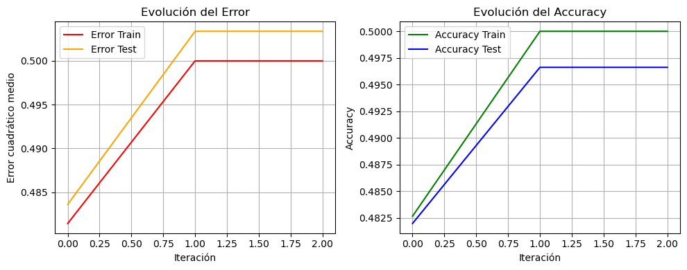

```python
visualizar_entrenamiento(errores_train, accuracy_train, errores_test, accuracy_test)
```

Podemos ver que el modelo no resulta muy eficiente, y de hecho converge rapidísimo. La razón de esto se explicará luego en el informe, pero veamos qué pasa si normalizamos la matriz X inicial

```python
X_train_norm = X_train / 255.0
X_test_norm = X_test / 255.0
```

Implementamos nuevamente el método de Descenso por Gradiente

```python
size = 128
alpha = 0.01
repeticiones = 1000

w_final, b_final, errores_train_norm, accuracy_train_norm, errores_test_norm, accuracy_test_norm = entrenar_descenso_gradiente(
    X_train_norm, y_train, X_test_norm, y_test, size, alpha, repeticiones)
```

```
Iniciando entrenamiento con:
  - Tamaño de imagen: 128
  - Alpha: 0.01

Iteración 0, Error Train: 0.2540, Accuracy Train: 0.5000 | Error Test: 0.2536, Accuracy Test: 0.5034
Convergencia alcanzada en la iteración 2
```

Graficamos los resultados

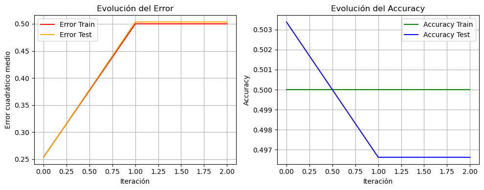

```python
visualizar_entrenamiento(errores_train_norm, accuracy_train_norm, errores_test_norm, accuracy_test_norm)
```

```
Iniciando entrenamiento con:
  - Tamaño de imagen: 128
  - Alpha: 0.1

Iteración 0, Error Train: 0.2500, Accuracy Train: 0.4987 | Error Test: 0.2497, Accuracy Test: 0.5011
Convergencia alcanzada en la iteración 2
```

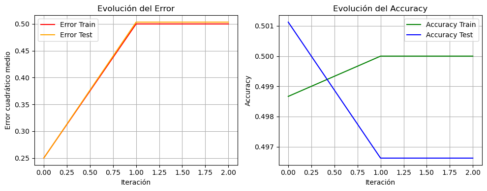

```
Iniciando entrenamiento con:
  - Tamaño de imagen: 128
  - Alpha: 0.01

Iteración 0, Error Train: 0.2502, Accuracy Train: 0.5093 | Error Test: 0.2502, Accuracy Test: 0.5113
Convergencia alcanzada en la iteración 3
```

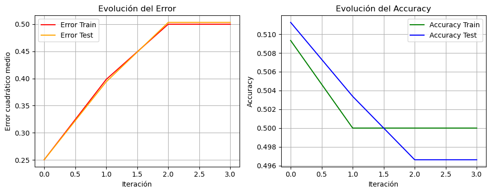

```
Iniciando entrenamiento con:
  - Tamaño de imagen: 128
  - Alpha: 0.001

Iteración 0, Error Train: 0.2515, Accuracy Train: 0.5000 | Error Test: 0.2517, Accuracy Test: 0.4966
Iteración 100, Error Train: 0.3098, Accuracy Train: 0.5000 | Error Test: 0.3102, Accuracy Test: 0.4966
Iteración 200, Error Train: 0.3397, Accuracy Train: 0.5000 | Error Test: 0.3401, Accuracy Test: 0.4966
Iteración 300, Error Train: 0.4577, Accuracy Train: 0.5000 | Error Test: 0.4532, Accuracy Test: 0.5034
Iteración 400, Error Train: 0.4523, Accuracy Train: 0.5000 | Error Test: 0.4477, Accuracy Test: 0.5034
Iteración 500, Error Train: 0.2429, Accuracy Train: 0.5047 | Error Test: 0.2440, Accuracy Test: 0.5000
Iteración 600, Error Train: 0.2577, Accuracy Train: 0.5000 | Error Test: 0.2572, Accuracy Test: 0.5034
Iteración 700, Error Train: 0.4546, Accuracy Train: 0.5000 | Error Test: 0.4563, Accuracy Test: 0.4966
Iteración 800, Error Train: 0.3961, Accuracy Train: 0.5000 | Error Test: 0.3973, Accuracy Test: 0.4966
Iteración 900, Error Train: 0.4335, Accuracy Train: 0.5000 | Error Test: 0.4349, Accuracy Test: 0.4966
Iteración 999, Error Train: 0.3458, Accuracy Train: 0.5000 | Error Test: 0.3422, Accuracy Test: 0.5034
```

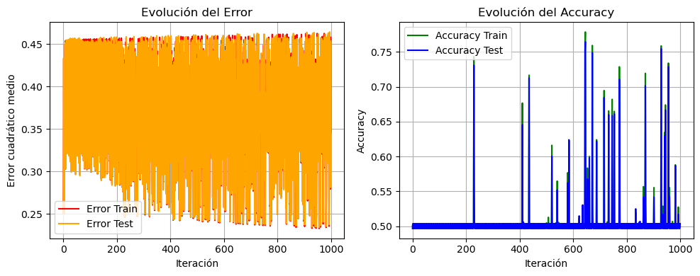

```
Iniciando entrenamiento con:
  - Tamaño de imagen: 128
  - Alpha: 0.0001

Iteración 0, Error Train: 0.2702, Accuracy Train: 0.5000 | Error Test: 0.2707, Accuracy Test: 0.4966
Iteración 100, Error Train: 0.2496, Accuracy Train: 0.5220 | Error Test: 0.2497, Accuracy Test: 0.5236
Iteración 200, Error Train: 0.2492, Accuracy Train: 0.5487 | Error Test: 0.2493, Accuracy Test: 0.5428
Iteración 300, Error Train: 0.2488, Accuracy Train: 0.5613 | Error Test: 0.2490, Accuracy Test: 0.5529
Iteración 400, Error Train: 0.2485, Accuracy Train: 0.5760 | Error Test: 0.2486, Accuracy Test: 0.5642
Iteración 500, Error Train: 0.2481, Accuracy Train: 0.5973 | Error Test: 0.2483, Accuracy Test: 0.5867
Iteración 600, Error Train: 0.2477, Accuracy Train: 0.6173 | Error Test: 0.2479, Accuracy Test: 0.6059
Iteración 700, Error Train: 0.2473, Accuracy Train: 0.6413 | Error Test: 0.2476, Accuracy Test: 0.6284
Iteración 800, Error Train: 0.2469, Accuracy Train: 0.6547 | Error Test: 0.2472, Accuracy Test: 0.6374
Iteración 900, Error Train: 0.2466, Accuracy Train: 0.6660 | Error Test: 0.2469, Accuracy Test: 0.6475
Iteración 999, Error Train: 0.2462, Accuracy Train: 0.6780 | Error Test: 0.2466, Accuracy Test: 0.6588
```

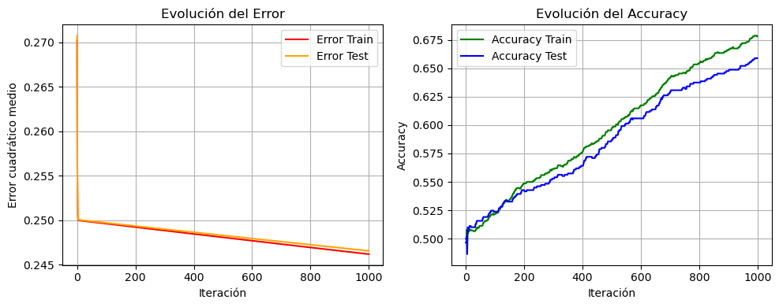

```
Iniciando entrenamiento con:
  - Tamaño de imagen: 128
  - Alpha: 1e-05

Iteración 0, Error Train: 0.2529, Accuracy Train: 0.5000 | Error Test: 0.2528, Accuracy Test: 0.5034
Convergencia alcanzada en la iteración 55
```

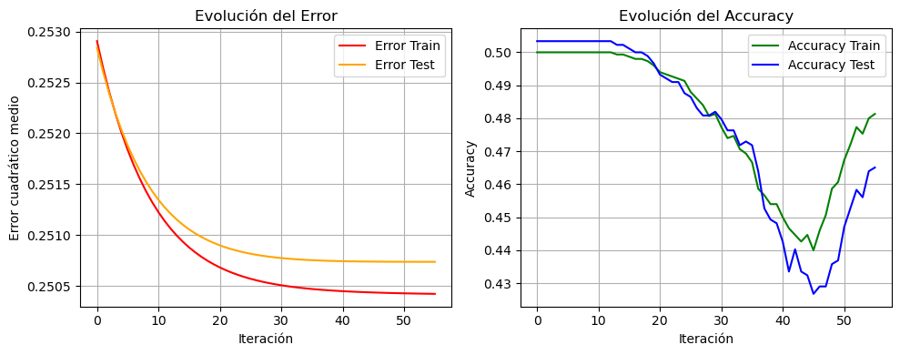

```python
alphas = [0.1, 0.01, 0.001, 0.0001, 0.00001]

size = 128
repeticiones = 1000

for alpha in alphas:
    w_final, b_final, errores_train_norm, accuracy_train_norm, errores_test_norm, accuracy_test_norm = entrenar_descenso_gradiente(
        X_train_norm, y_train, X_test_norm, y_test, size, alpha, repeticiones)
    visualizar_entrenamiento(errores_train_norm, accuracy_train_norm, errores_test_norm, accuracy_test_norm)
```

Pareciera que para 0.0001 funciona bastante bien. Ahora analicemos la optimización de otra variable: el size

```
Iniciando entrenamiento con:
  - Tamaño de imagen: 32
  - Alpha: 0.0001

Iteración 0, Error Train: 0.2571, Accuracy Train: 0.5000 | Error Test: 0.2564, Accuracy Test: 0.5034
Iteración 100, Error Train: 0.2494, Accuracy Train: 0.5440 | Error Test: 0.2494, Accuracy Test: 0.5484
Iteración 200, Error Train: 0.2490, Accuracy Train: 0.5860 | Error Test: 0.2491, Accuracy Test: 0.5800
Iteración 300, Error Train: 0.2486, Accuracy Train: 0.6287 | Error Test: 0.2487, Accuracy Test: 0.6261
Iteración 400, Error Train: 0.2483, Accuracy Train: 0.6567 | Error Test: 0.2484, Accuracy Test: 0.6622
Iteración 500, Error Train: 0.2479, Accuracy Train: 0.6813 | Error Test: 0.2480, Accuracy Test: 0.6892
Iteración 600, Error Train: 0.2475, Accuracy Train: 0.7013 | Error Test: 0.2477, Accuracy Test: 0.7095
Iteración 700, Error Train: 0.2471, Accuracy Train: 0.7193 | Error Test: 0.2473, Accuracy Test: 0.7252
Iteración 800, Error Train: 0.2467, Accuracy Train: 0.7260 | Error Test: 0.2470, Accuracy Test: 0.7275
Iteración 900, Error Train: 0.2464, Accuracy Train: 0.7427 | Error Test: 0.2466, Accuracy Test: 0.7399
Iteración 999, Error Train: 0.2460, Accuracy Train: 0.7567 | Error Test: 0.2463, Accuracy Test: 0.7545
Tiempo de entrenamiento: 141.17 segundos
```

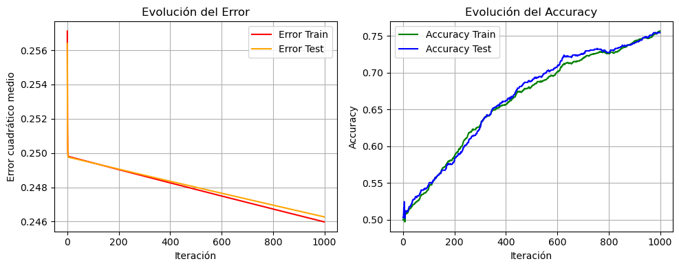

```
Iniciando entrenamiento con:
  - Tamaño de imagen: 64
  - Alpha: 0.0001

Iteración 0, Error Train: 0.2509, Accuracy Train: 0.5000 | Error Test: 0.2512, Accuracy Test: 0.4966
Iteración 100, Error Train: 0.2496, Accuracy Train: 0.5420 | Error Test: 0.2497, Accuracy Test: 0.5191
Iteración 200, Error Train: 0.2492, Accuracy Train: 0.5833 | Error Test: 0.2493, Accuracy Test: 0.5597
Iteración 300, Error Train: 0.2488, Accuracy Train: 0.6200 | Error Test: 0.2490, Accuracy Test: 0.6025
Iteración 400, Error Train: 0.2484, Accuracy Train: 0.6573 | Error Test: 0.2486, Accuracy Test: 0.6430
Iteración 500, Error Train: 0.2480, Accuracy Train: 0.6793 | Error Test: 0.2483, Accuracy Test: 0.6644
Iteración 600, Error Train: 0.2476, Accuracy Train: 0.6940 | Error Test: 0.2479, Accuracy Test: 0.6802
Iteración 700, Error Train: 0.2473, Accuracy Train: 0.7153 | Error Test: 0.2476, Accuracy Test: 0.7005
Iteración 800, Error Train: 0.2469, Accuracy Train: 0.7287 | Error Test: 0.2472, Accuracy Test: 0.7128
Iteración 900, Error Train: 0.2465, Accuracy Train: 0.7373 | Error Test: 0.2469, Accuracy Test: 0.7162
Iteración 999, Error Train: 0.2461, Accuracy Train: 0.7547 | Error Test: 0.2466, Accuracy Test: 0.7376
Tiempo de entrenamiento: 135.53 segundos
```

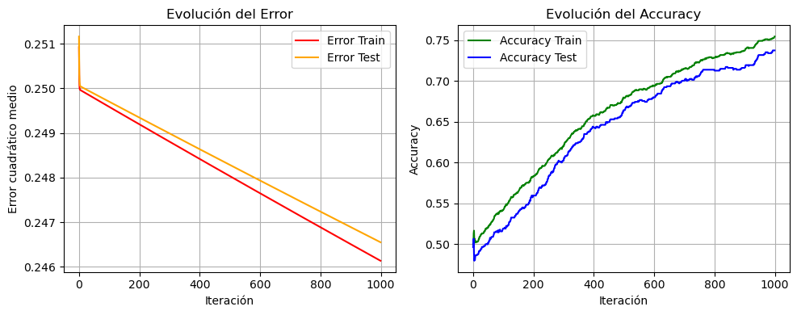

```
Iniciando entrenamiento con:
  - Tamaño de imagen: 128
  - Alpha: 0.0001

Iteración 0, Error Train: 0.2505, Accuracy Train: 0.5000 | Error Test: 0.2506, Accuracy Test: 0.4966
Iteración 100, Error Train: 0.2498, Accuracy Train: 0.5147 | Error Test: 0.2498, Accuracy Test: 0.5068
Iteración 200, Error Train: 0.2494, Accuracy Train: 0.5447 | Error Test: 0.2495, Accuracy Test: 0.5315
Iteración 300, Error Train: 0.2490, Accuracy Train: 0.5660 | Error Test: 0.2491, Accuracy Test: 0.5495
Iteración 400, Error Train: 0.2486, Accuracy Train: 0.5947 | Error Test: 0.2488, Accuracy Test: 0.5664
Iteración 500, Error Train: 0.2482, Accuracy Train: 0.6220 | Error Test: 0.2484, Accuracy Test: 0.5968
Iteración 600, Error Train: 0.2478, Accuracy Train: 0.6440 | Error Test: 0.2481, Accuracy Test: 0.6194
Iteración 700, Error Train: 0.2475, Accuracy Train: 0.6547 | Error Test: 0.2477, Accuracy Test: 0.6363
Iteración 800, Error Train: 0.2471, Accuracy Train: 0.6747 | Error Test: 0.2474, Accuracy Test: 0.6633
Iteración 900, Error Train: 0.2467, Accuracy Train: 0.6867 | Error Test: 0.2470, Accuracy Test: 0.6745
Iteración 999, Error Train: 0.2463, Accuracy Train: 0.6973 | Error Test: 0.2467, Accuracy Test: 0.6824
Tiempo de entrenamiento: 131.34 segundos
```

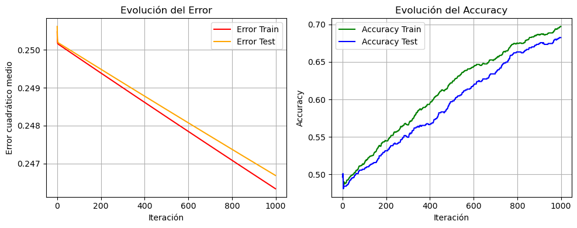

```
Iniciando entrenamiento con:
  - Tamaño de imagen: 256
  - Alpha: 0.0001

Iteración 0, Error Train: 0.2562, Accuracy Train: 0.5000 | Error Test: 0.2566, Accuracy Test: 0.4966
Iteración 100, Error Train: 0.2497, Accuracy Train: 0.5247 | Error Test: 0.2497, Accuracy Test: 0.5225
Iteración 200, Error Train: 0.2493, Accuracy Train: 0.5507 | Error Test: 0.2494, Accuracy Test: 0.5507
Iteración 300, Error Train: 0.2490, Accuracy Train: 0.5753 | Error Test: 0.2490, Accuracy Test: 0.5687
Iteración 400, Error Train: 0.2486, Accuracy Train: 0.5920 | Error Test: 0.2487, Accuracy Test: 0.5811
Iteración 500, Error Train: 0.2482, Accuracy Train: 0.6120 | Error Test: 0.2483, Accuracy Test: 0.5923
Iteración 600, Error Train: 0.2478, Accuracy Train: 0.6293 | Error Test: 0.2480, Accuracy Test: 0.6104
Iteración 700, Error Train: 0.2474, Accuracy Train: 0.6393 | Error Test: 0.2476, Accuracy Test: 0.6216
Iteración 800, Error Train: 0.2470, Accuracy Train: 0.6547 | Error Test: 0.2473, Accuracy Test: 0.6363
Iteración 900, Error Train: 0.2467, Accuracy Train: 0.6673 | Error Test: 0.2469, Accuracy Test: 0.6453
Iteración 999, Error Train: 0.2463, Accuracy Train: 0.6840 | Error Test: 0.2466, Accuracy Test: 0.6610
Tiempo de entrenamiento: 127.00 segundos
```

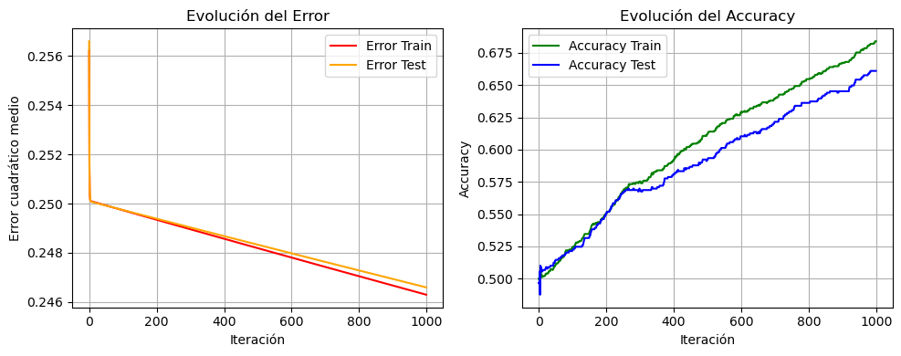

```python
sizes = [32, 64, 128, 256]

alpha = 0.0001
repeticiones = 1000

for size in sizes:
    start_time = time.time()

    w_final, b_final, errores_train_norm, accuracy_train_norm, errores_test_norm, accuracy_test_norm = entrenar_descenso_gradiente(
        X_train_norm, y_train, X_test_norm, y_test, size, alpha, repeticiones)

    elapsed_time = time.time() - start_time
    print(f"Tiempo de entrenamiento: {elapsed_time:.2f} segundos")

    visualizar_entrenamiento(errores_train_norm, accuracy_train_norm, errores_test_norm, accuracy_test_norm)
```

Generamos la matriz de confusión para alpha = 0.0001

```python
# Función de matriz de confusión (usando vectores X e y)
def matriz_confusion(X, y, w, b, umbral=0.5):
    vp = 0
    fp = 0
    vn = 0
    fn = 0

    z = X @ w + b
    pred = (np.tanh(z) + 1) / 2
    clases_predichas = (pred > umbral).astype(int).flatten()

    for real, pred in zip(y, clases_predichas):
        if real == 1 and pred == 1:
            vp += 1
        elif real == 0 and pred == 1:
            fp += 1
        elif real == 0 and pred == 0:
            vn += 1
        elif real == 1 and pred == 0:
            fn += 1

    # Retornamos en orden para que coincida con la matriz visual
    return vn, fp, fn, vp
```

```python
def graficar_matrices_confusion(matriz_train, matriz_test):
    etiquetas = ["Pred Healthy", "Pred Parkinson"]
    filas = ["True Healthy", "True Parkinson"]

    fig, axes = plt.subplots(1, 2, figsize=(8, 4))

    sns.heatmap(matriz_train, annot=True, fmt="d", cmap="Greens", cbar=False,
                xticklabels=etiquetas, yticklabels=filas, ax=axes[0])
    axes[0].set_title("Train")
    axes[0].set_xlabel("")
    axes[0].set_ylabel("")

    sns.heatmap(matriz_test, annot=True, fmt="d", cmap="Greens", cbar=False,
                xticklabels=etiquetas, yticklabels=filas, ax=axes[1])
    axes[1].set_title("Test")
    axes[1].set_xlabel("")
    axes[1].set_ylabel("")

    plt.tight_layout()
    plt.show()
```

```
Iniciando entrenamiento con:
  - Tamaño de imagen: 64
  - Alpha: 0.0001

Iteración 0, Error Train: 0.2544, Accuracy Train: 0.5000 | Error Test: 0.2540, Accuracy Test: 0.5034
Iteración 100, Error Train: 0.2495, Accuracy Train: 0.5473 | Error Test: 0.2497, Accuracy Test: 0.5439
Iteración 200, Error Train: 0.2491, Accuracy Train: 0.5813 | Error Test: 0.2493, Accuracy Test: 0.5709
Iteración 300, Error Train: 0.2487, Accuracy Train: 0.6087 | Error Test: 0.2490, Accuracy Test: 0.5968
Iteración 400, Error Train: 0.2484, Accuracy Train: 0.6313 | Error Test: 0.2486, Accuracy Test: 0.6149
Iteración 500, Error Train: 0.2480, Accuracy Train: 0.6520 | Error Test: 0.2483, Accuracy Test: 0.6273
Iteración 600, Error Train: 0.2476, Accuracy Train: 0.6633 | Error Test: 0.2479, Accuracy Test: 0.6363
Iteración 700, Error Train: 0.2472, Accuracy Train: 0.6780 | Error Test: 0.2476, Accuracy Test: 0.6430
Iteración 800, Error Train: 0.2468, Accuracy Train: 0.6900 | Error Test: 0.2472, Accuracy Test: 0.6599
Iteración 900, Error Train: 0.2465, Accuracy Train: 0.7020 | Error Test: 0.2469, Accuracy Test: 0.6723
Iteración 999, Error Train: 0.2461, Accuracy Train: 0.7147 | Error Test: 0.2465, Accuracy Test: 0.6914
```

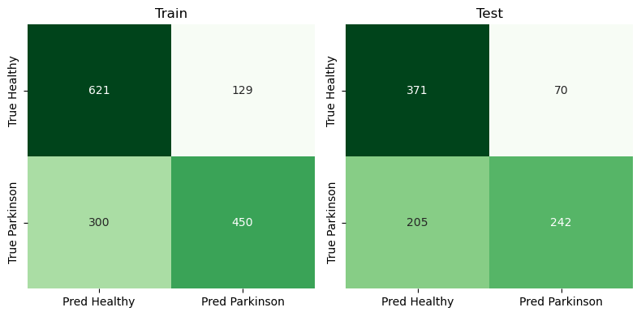

```python
size = 64
alpha = 0.0001
repeticiones = 1000

w_final, b_final, errores_train_norm, accuracy_train_norm, errores_test_norm, accuracy_test_norm = entrenar_descenso_gradiente(
    X_train_norm, y_train, X_test_norm, y_test, size, alpha, repeticiones)

vn, fp, fn, vp = matriz_confusion(X_train, y_train, w_final, b_final)
matriz_train = np.array([[vn, fp], [fn, vp]])

vn, fp, fn, vp = matriz_confusion(X_test, y_test, w_final, b_final)
matriz_test = np.array([[vn, fp], [fn, vp]])

graficar_matrices_confusion(matriz_train, matriz_test)
```